# Exemplo de análises em NLP

```r
library(knitr)
library(xml2)
library(rvest)
library(dplyr)
library(purrr)
library(tidyr)
library(tidytext)
library(ggplot2)
library(ggraph)
```

# Data import

Importa os textos da Bíblia em XML para um dataframe. Para condensar o exemplo, são usados apenas os quatro primeiros livros.

```r
url <- "https://raw.githubusercontent.com/thiagobodruk/biblia/master/xml/nvi.min.xml"

books <- read_xml(url) %>%
  xml_children()

books_names <- xml_attr(books, "name")

old_testament <- books_names[1:which(books_names == "Malaquias")]

read_chapter <- function(chapter, n) {
  text <- chapter %>%
    xml_children() %>%
    xml_text()

  tibble(capitulo = n, versiculo = seq_along(text), text = text)
}

read_book <- function(book) {
  book_name <- xml_attr(book, "name")

  chapters <- xml_children(book)

  imap_dfr(chapters, ~read_chapter(.x, .y)) %>%
    mutate(livro = book_name,
           testamento = if_else(livro %in% old_testament,
                                "Velho Testamento",
                                "Novo Testamento")) %>%
    select(testamento, livro, everything())
}

bible <- books %>%
  map_dfr(read_book) %>%
  mutate(livro = factor(livro, levels = xml_attr(books, "name")))

bible <- books %>%
  map_dfr(read_book) %>%
  mutate(testamento = factor(testamento, levels = c("Velho Testamento",
                                                    "Novo Testamento")),
         livro = factor(livro, levels = books_names))

readr::write_csv(bible, "datasets/bible.csv")
```

Por brevidade, vamos utilizar somente os 4 primeiros livros da Bíblia.

```r
bible <- filter(bible, livro %in% books_names[1:4])

# Print `bible` sample
sample_n(bible, 10)
```

| testamento | livro | capitulo | versiculo | text |
| --- | --- | --- | --- | --- |
| Velho Testamento | Êxodo | 15 | 19 | Quando os cavalos, os carros de guerra e os cavaleiros do faraó entraram no mar, o Senhor fez que as águas do mar se voltassem sobre eles, mas os israelitas atravessaram o mar pisando em terra seca. |
| Velho Testamento | Números | 32 | 20 | Disse-lhes Moisés: "Se fizerem isso, se perante o Senhor vocês se armarem para a guerra, |
| Velho Testamento | Êxodo | 19 | 24 | O Senhor respondeu: "Desça e depois torne a subir, acompanhado de Arão. Quanto aos sacerdotes e ao povo, não devem ultrapassar o limite para subir ao Senhor; senão, o Senhor os fulminará". |
| Velho Testamento | Êxodo | 15 | 26 | dizendo-lhes: "Se vocês derem atenção ao Senhor, ao seu Deus e fizerem o que ele aprova, se derem ouvidos aos seus mandamentos e obedecerem a todos os seus decretos, não trarei sobre vocês nenhuma das… |
| Velho Testamento | Números | 28 | 22 | Ofereçam um bode como sacrifício pela culpa, para fazer propiciação por vocês. |
| Velho Testamento | Levítico | 4 | 26 | Queimará toda a gordura no altar, como queimou a gordura do sacrifício de comunhão. Assim o sacerdote fará propiciação pelo pecado do líder, e ele será perdoado. |
| Velho Testamento | Êxodo | 21 | 25 | queimadura por queimadura, ferida por ferida, contusão por contusão. |
| Velho Testamento | Gênesis | 25 | 10 | campo que Abraão comprara dos hititas. Foi ali que Abraão e Sara, sua mulher, foram sepultados. |
| Velho Testamento | Gênesis | 1 | 8 | Ao firmamento Deus chamou céu. Passaram-se a tarde e a manhã; esse foi o segundo dia. |
| Velho Testamento | Gênesis | 50 | 12 | Assim fizeram os filhos de Jacó o que este lhes havia ordenado: |

# Pré-processamento

## Tokenização

Separa o texto em palavras (*tokens*). São removidos caracteres especiais, como ponto final e vírgula, e para a língua portuguesa é interessante remover acentos e cedilhas.

```r
df <- bible %>%
  unnest_tokens(word, text) %>%
  mutate(word = stringi::stri_trans_general(word, "Latin-ASCII"))

# Print `df` head
head(df, 10)
```

| testamento | livro | capitulo | versiculo | word |
| --- | --- | --- | --- | --- |
| Velho Testamento | Gênesis | 1 | 1 | no |
| Velho Testamento | Gênesis | 1 | 1 | principio |
| Velho Testamento | Gênesis | 1 | 1 | deus |
| Velho Testamento | Gênesis | 1 | 1 | criou |
| Velho Testamento | Gênesis | 1 | 1 | os |
| Velho Testamento | Gênesis | 1 | 1 | ceus |
| Velho Testamento | Gênesis | 1 | 1 | e |
| Velho Testamento | Gênesis | 1 | 1 | a |
| Velho Testamento | Gênesis | 1 | 1 | terra |
| Velho Testamento | Gênesis | 1 | 2 | era |

## Stop-words

Normalmente, as palavras mais comuns (frequentes) são artigos (o, umas), advérbios (muitas, pouco), conjunções (de, para), etc, que não adicionam valor à análise.

```r
df %>%
  group_by(livro) %>%
  count(word) %>%
  top_n(10, n) %>%
  ungroup() %>%
  arrange(livro, desc(n))
```

| livro | word | n |
| --- | --- | --- |
| Gênesis | e | 1752 |
| Gênesis | a | 1226 |
| Gênesis | de | 1209 |
| Gênesis | o | 1096 |
| Gênesis | que | 911 |
| Gênesis | os | 624 |
| Gênesis | se | 411 |
| Gênesis | para | 373 |
| Gênesis | do | 372 |
| Gênesis | seu | 322 |

[output cut: 30 more lines]

Por esse motivo, é útil remover esse conjunto de palavras, referidas como *stop-words* para analisarmos palavras mais interessantes.

```r
stop_words <- tibble(word = tm::stopwords(kind = "pt-BR")) %>%
  mutate(word = stringi::stri_trans_general(word, "Latin-ASCII"))

df_clean <- df %>%
  anti_join(stop_words, by = "word")
```

# Análise

## Word count

Contagem de palavras mais frequentes.

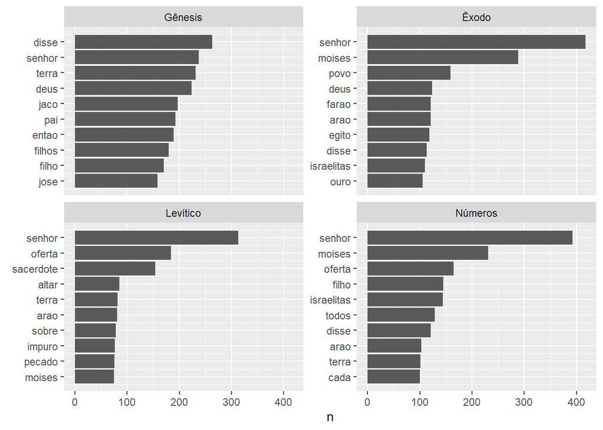

```r
word_count <- df_clean %>%
  group_by(livro) %>%
  count(word) %>%
  top_n(10, n) %>%
  ungroup() %>%
  arrange(livro, n) %>%
  mutate(order = row_number())

ggplot(word_count, aes(x = order, y = n)) +
  geom_col() +
  coord_flip() +
  facet_wrap(~ livro, scales = "free_y") +
  scale_x_continuous(breaks = word_count$order,
                     labels = word_count$word) +
  xlab(element_blank())
```

## Tf-Idf

> A estatística **tf-idf** tem o objetivo de medir quão importante uma palavra é para um documento em um *coleção* de documentos (corpus).

Nesse caso, um documento aqui é um livro da Bíblia e o corpus é o conjunto desses livros (a Bíblia). Tf-idf é obtido pela multiplicação de duas quantidades:

- *term frequency*: a frequência com que uma palavra aparece em um documento;
- *inverse document frequency*: é uma medida de quanta informação uma palavra fornece, ou seja, se o termo é comum ou raro em relação a todos os documentos.

```r
df_tfidf <- df %>%
  count(livro, word, sort = TRUE) %>%
  bind_tf_idf(word, livro, n)

df_tfidf
```

| livro | word | n | tf | idf | tf_idf |
| --- | --- | --- | --- | --- | --- |
| Gênesis | e | 1752 | 5.313277e-02 | 0.0000000 | 0.000000e+00 |
| Números | de | 1465 | 5.461731e-02 | 0.0000000 | 0.000000e+00 |
| Êxodo | e | 1372 | 5.097908e-02 | 0.0000000 | 0.000000e+00 |
| Êxodo | o | 1272 | 4.726340e-02 | 0.0000000 | 0.000000e+00 |
| Gênesis | a | 1226 | 3.718081e-02 | 0.0000000 | 0.000000e+00 |
| Gênesis | de | 1209 | 3.666525e-02 | 0.0000000 | 0.000000e+00 |
| Números | e | 1196 | 4.458860e-02 | 0.0000000 | 0.000000e+00 |
| Gênesis | o | 1096 | 3.323831e-02 | 0.0000000 | 0.000000e+00 |
| Êxodo | de | 1046 | 3.886598e-02 | 0.0000000 | 0.000000e+00 |
| Levítico | o | 939 | 4.709836e-02 | 0.0000000 | 0.000000e+00 |

[output cut: 9990 more lines]

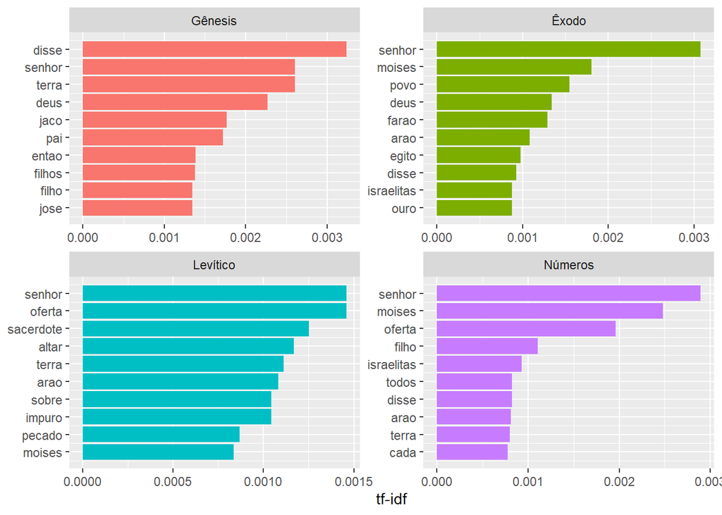

```r
df_tfidf %>%
  group_by(livro) %>%
  top_n(10) %>%
  ungroup() %>%
  arrange(livro, tf_idf) %>%
  mutate(order = row_number()) %>%
  ggplot(aes(order, tf_idf, fill = livro)) +
  geom_col(show.legend = FALSE) +
  labs(x = NULL, y = "tf-idf") +
  facet_wrap(~livro, ncol = 2, scales = "free") +
  coord_flip() +
  scale_x_continuous(breaks = word_count$order,
                     labels = word_count$word)
```

## Análise de sentimento

A análise de sentimento (positivo, neutro ou negativo) pode ser feita através de um dicionário léxico (*lexicon*) de palavras, em que são dados valores ou classificações para cada palavra. Existem diversos dicionários, cujo eficácia pode variar com o tipo linguagem usada no contexto (mais formal, época da escrita, etc).

```r
lexicon <- lexiconPT::sentiLex_lem_PT02 %>%
  as_tibble() %>%
  select(word = term, grammar_category, value = polarity) %>%
  mutate(grammar_category = case_when(grammar_category == "N" ~ "noun",
                                      grammar_category == "Adj" ~ "adjective",
                                      grammar_category == "V" ~ "verb",
                                      grammar_category == "IDIOM" ~ "idiom",
                                      TRUE ~ grammar_category))

lexicon
```

| word | grammar_category | value |
| --- | --- | --- |
| a-vontade | noun | 1 |
| abafado | adjective | -1 |
| abafante | adjective | -1 |
| abaixado | adjective | -1 |
| abalado | adjective | -1 |
| abalizado | adjective | 1 |
| abalroado | adjective | -1 |
| abalroar | verb | 1 |
| abanar | verb | 1 |
| abandalhado | adjective | -1 |

[output cut: 7004 more lines]

```r
lexicon_stem <- lexicon %>%
  mutate(word = SnowballC::wordStem(word, language = "portuguese")) %>%
  distinct()

lexicon_stem
```

| word | grammar_category | value |
| --- | --- | --- |
| a-vontad | noun | 1 |
| abaf | adjective | -1 |
| abaix | adjective | -1 |
| abal | adjective | -1 |
| abaliz | adjective | 1 |
| abalro | adjective | -1 |
| abalro | verb | 1 |
| aban | verb | 1 |
| abandalh | adjective | -1 |
| abandalh | noun | -1 |

[output cut: 6710 more lines]

No caso desse dicionário, poucas palavras foram encontradas (cerca de 2%). Pode ser útil aplicar normalização de palavras com técnicas como [stemming](https://en.wikipedia.org/wiki/Stemming) e [lemmatisation](https://en.wikipedia.org/wiki/Lemmatisation), que reduzem variações de uma palavra à sua raiz ou informação morfológica. A aplicação de *word stemming* tanto para aos tokens como ao dicionário léxico aumenta as palavras encontradas para cerca de 30%, porém é necessário verificar se o sentido é preservado.

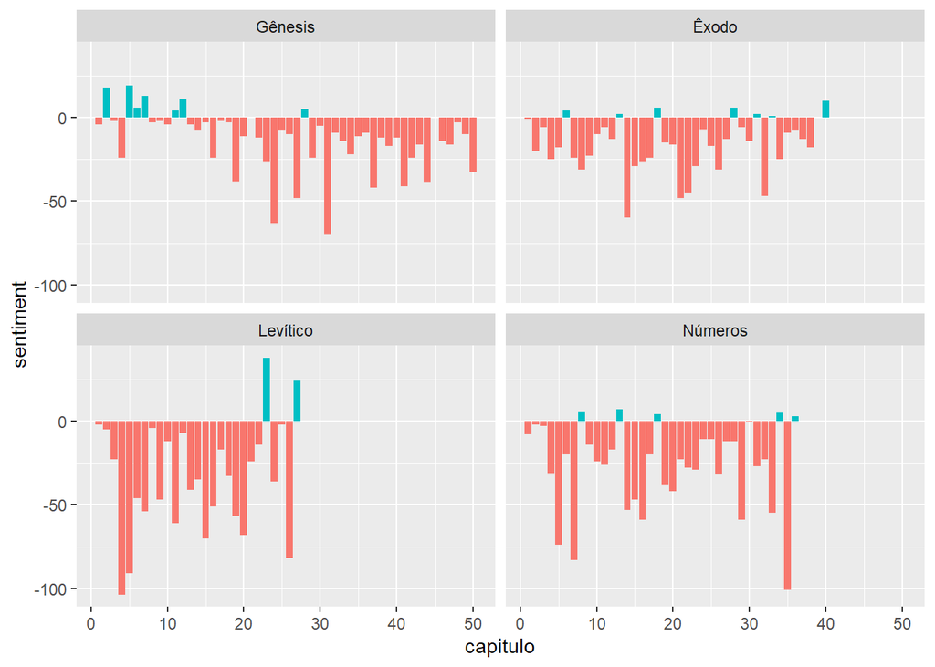

```r
df_clean %>%
  mutate(word = SnowballC::wordStem(word, language = "portuguese")) %>%
  inner_join(lexicon_stem, by = "word") %>%
  group_by(livro, capitulo) %>%
  summarise(sentiment = sum(value)) %>%
  ungroup() %>%
  ggplot(aes(x = capitulo, y = sentiment, fill = sentiment > 0)) +
  geom_col() +
  guides(fill = FALSE) +
  facet_wrap(~ livro)
```

# N-grams

Algumas vezes é interessante olhar para conjunto de palavras, ao invés de palavras individuais (*tokens*). Assim, pode-se analisar a relação entre palavras.

```r
bigrams <- bible %>%
  unnest_tokens(bigram, text, token = "ngrams", n = 2) %>%
  mutate(bigram = stringi::stri_trans_general(bigram, "Latin-ASCII"))

bigrams %>%
  count(bigram, sort = TRUE)
```

| bigram | n |
| --- | --- |
| o senhor | 793 |
| e o | 380 |
| e a | 308 |
| todos os | 308 |
| ao senhor | 284 |
| os seus | 274 |
| o que | 258 |
| a moises | 226 |
| e os | 224 |
| o seu | 222 |

[output cut: 9990 more lines]

```r
bigrams_clean <- bigrams %>%
  separate(bigram, c("word1", "word2"), sep = " ") %>%
  filter(!word1 %in% stop_words$word) %>%
  filter(!word2 %in% stop_words$word)

bigrams_clean %>%
  count(word1, word2, sort = TRUE)
```

| word1 | word2 | n |
| --- | --- | --- |
| senhor | disse | 94 |
| sete | dias | 55 |
| entao | moises | 44 |
| melhor | farinha | 44 |
| aroma | agradavel | 37 |
| setimo | dia | 36 |
| ficara | impuro | 32 |
| linho | fino | 32 |
| decreto | perpetuo | 30 |
| farinha | amassada | 30 |

[output cut: 9990 more lines]

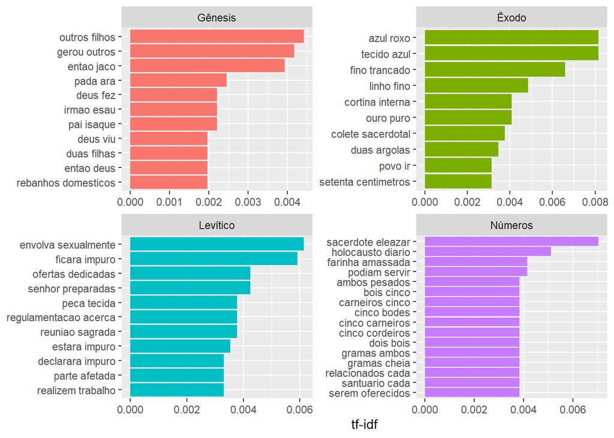

```r
bigrams_clean %>%
  unite(bigram, word1, word2, sep = " ") %>%
  count(livro, bigram) %>%
  bind_tf_idf(bigram, livro, n) %>%
  arrange(desc(tf_idf)) %>%
  mutate(bigram = factor(bigram, levels = rev(unique(bigram)))) %>%
  group_by(livro) %>%
  top_n(10) %>%
  ungroup() %>%
  ggplot(aes(bigram, tf_idf, fill = livro)) +
  geom_col(show.legend = FALSE) +
  labs(x = NULL, y = "tf-idf") +
  facet_wrap(~livro, ncol = 2, scales = "free") +
  coord_flip()
```

Em análise de sentimento, é fundamental olhar a relação entre palavras. Por exemplo, o sentimento da palavra “gostar” pode ser positivo, mas, se dissermos “**Não** gostei”, o sentimento associado é contrário.

```r
bigrams %>%
  separate(bigram, c("word1", "word2"), sep = " ") %>%
  filter(word1 == "nao") %>%
  count(word2, sort = TRUE, .drop = FALSE)
```

| word2 | n |
| --- | --- |
| se | 81 |
| o | 28 |
| podera | 27 |
| poderao | 20 |
| sera | 20 |
| me | 18 |
| tiver | 18 |
| lhe | 17 |
| facam | 16 |
| os | 13 |

[output cut: 363 more lines]

## Rede de bigramas

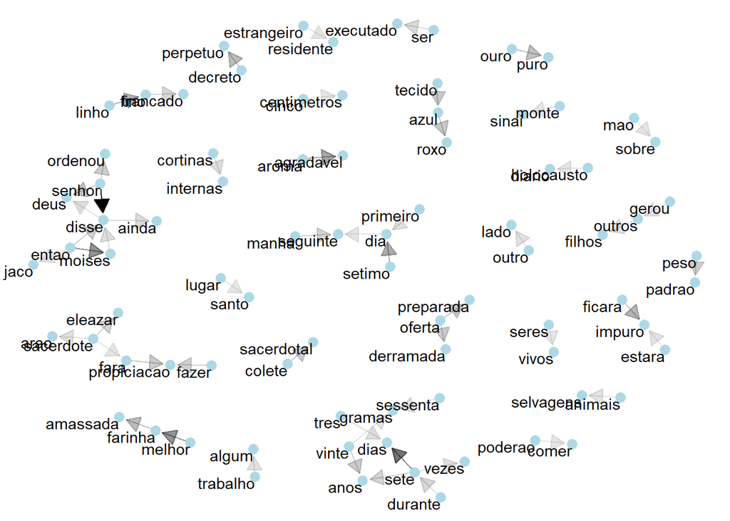

```r
bigram_graph <- bigrams_clean %>%
  count(word1, word2, sort = TRUE) %>%
  filter(n > 15) %>%
  igraph::graph_from_data_frame()

a <- grid::arrow(type = "closed", length = unit(.15, "inches"))

ggraph(bigram_graph, layout = "fr") +
  geom_edge_link(aes(edge_alpha = n), show.legend = FALSE,
                 arrow = a, end_cap = circle(.07, 'inches')) +
  geom_node_point(color = "lightblue", size = 3) +
  geom_node_text(aes(label = name), vjust = 1, hjust = 1) +
  theme_void()
```

# Matriz documento-termo

A matriz documento-termo é comumente usada na construção de modelos, onde cada linha $i$ da matriz representa um documento e cada coluna $j$ (variável) representa uma palavra. Os valores da matriz podem ser indicar se a palavra $j$ está presente no documento $i$ (dummy variable) ou valores de tf-idf, por exemplo.

```r
dtm <- df %>%
  count(livro, word) %>%
  mutate(livro = as.character(livro)) %>%
  cast_dtm(livro, word, n, weighting = tm::weightTfIdf) %>%
  as.matrix()

dtm[, 1000:1005]
```

```
##           Terms
## Docs              cruel     cruzando        cubra      cuidado     cuidados
##   Gênesis  3.032692e-05 6.065385e-05 6.065385e-05 6.293405e-05 0.0002122885
##   Êxodo    1.114703e-04 0.000000e+00 0.000000e+00 7.710725e-05 0.0000000000
##   Levítico 0.000000e+00 0.000000e+00 0.000000e+00 0.000000e+00 0.0000501580
##   Números  0.000000e+00 0.000000e+00 0.000000e+00 3.094639e-05 0.0000000000
##           Terms
## Docs             cuidam
##   Gênesis  6.065385e-05
##   Êxodo    0.000000e+00
##   Levítico 0.000000e+00
##   Números  0.000000e+00
```

# Notas finais

Análise textuais e processamento de linguagem natural são temas em constante evolução, com novas técnicas e projetos inovadores surgindo de tempos em tempos. Existem outros refinamentos que podem ser feitos no tratamento do texto, além de uma variedade de algoritmos mais avançados para aplicações diversas, como Word2vec.